# W3cubDocs

### Using the command line

To deprecate an entire package, run the following command, replacing `<package-name>` with the name of your package, and `"<message>"` with your deprecation message:

```
npm deprecate <package-name> "<message>"
```

If you have enabled two-factor authentication, add a one-time password to the command, `--otp=123456` (where *123456* is the code from your authenticator app).

## Deprecating a single version of a package

When you deprecate a version of a package, a red message will be displayed on that version's package page, similar to deprecating an entire package.

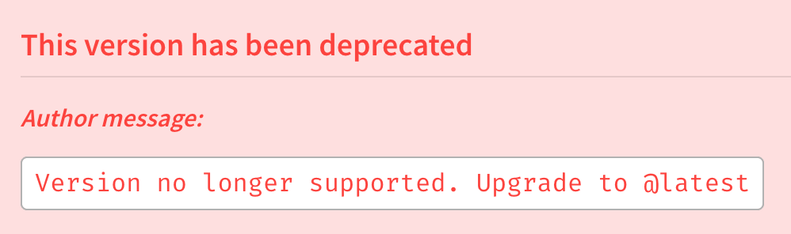

### Using the command line

To deprecate a package version, run the following command, replacing `<package-name>` with the name of your package, `<version>` with your version number, and `"<message>"` with your deprecation message:

```
npm deprecate <package-name>@<version> "<message>"
```

The CLI will also accept version ranges for `<version>`.

If you have two-factor auth, add a one-time password to the command, `--otp=123456` (where *123456* is the code from your authenticator).

## Undeprecating a package or version

To undeprecate a package, replace `"<message>"` with `""` (an empty string) in one of the above commands.

For example, to undeprecate a package version, run the following command, replacing `<package-name>` with the name of your package, and `<version>` with your version number:

```
npm deprecate <package-name>@<version> ""
```

If you have two-factor auth, add a one-time password to the command, `--otp=123456` (where *123456* is the code from your authenticator).

## Transferring a deprecated package to npm

If you are no longer maintaining a package, but other users depend on it, and you'd like to remove it from your user profile, you can transfer it to the [`@npm`](https://www.npmjs.com/~npm) user account, which is owned by the npm registry.

**Note:** Once you transfer a package to the npm account, you will no longer be able to update it.

To transfer a package to the npm user account, run the following two commands in order, replacing `<user>` with your npm user name, and `<package-name>` with the package you want to transfer:

```
npm owner add npm <package-name>
npm owner rm <user> <package-name>
```

If you have two-factor auth, add a one-time password to the command, `--otp=123456` (where *123456* is the code from your authenticator).